# Reproducible_Research_Assignment_1.Rmd

Carlos Abadi

2/7/2019

```r
df<-read.csv('/Users/carlosabadi/OneDrive - Abadi & Co/MOOCS/Data Science/activity.csv')
head(df)
```

```
##   steps       date interval
## 1    NA 2012-10-01        0
## 2    NA 2012-10-01        5
## 3    NA 2012-10-01       10
## 4    NA 2012-10-01       15
## 5    NA 2012-10-01       20
## 6    NA 2012-10-01       25
```

The variables included in this dataset are:

- **steps**: Number of steps taking in a 5-minute interval (missing values are coded as 𝙽𝙰)
- **date**: The date on which the measurement was taken in YYYY-MM-DD format
- **interval**: Identifier for the 5-minute interval in which measurement was taken

Then take a look at the data summary:

```r
summary(df)
```

```
##      steps                date          interval
##  Min.   :  0.00   2012-10-01:  288   Min.   :   0.0
##  1st Qu.:  0.00   2012-10-02:  288   1st Qu.: 588.8
##  Median :  0.00   2012-10-03:  288   Median :1177.5
##  Mean   : 37.38   2012-10-04:  288   Mean   :1177.5
##  3rd Qu.: 12.00   2012-10-05:  288   3rd Qu.:1766.2
##  Max.   :806.00   2012-10-06:  288   Max.   :2355.0
##  NA's   :2304     (Other)   :15840
```

### What is the mean number of steps taken per day?

For this part, ignore missing values.  
1. Calculate the total number of steps taken per day.

```r
steps_by_day<-aggregate(steps~date,df,sum)
head(steps_by_day,10)
```

```
##          date steps
## 1  2012-10-02   126
## 2  2012-10-03 11352
## 3  2012-10-04 12116
## 4  2012-10-05 13294
## 5  2012-10-06 15420
## 6  2012-10-07 11015
## 7  2012-10-09 12811
## 8  2012-10-10  9900
## 9  2012-10-11 10304
## 10 2012-10-12 17382
```

2. Make a histogram of the total number of steps taken each day.

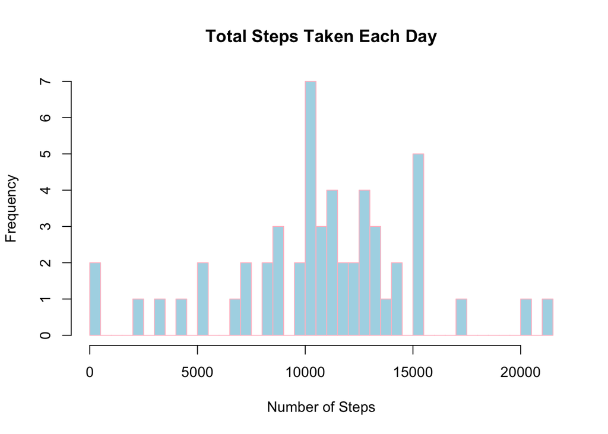

```r
hist(steps_by_day[,2],breaks=dim(steps_by_day)[1],col="lightblue",border="pink",main="Total Steps Taken Each Day",xlab="Number of Steps")
```

3. Calculate and report the mean and median of the total number of steps taken per day.

```r
mean(steps_by_day$steps)
```

```
## [1] 10766.19
```

```r
median(steps_by_day$steps)
```

```
## [1] 10765
```

## What is the average daily activity pattern?

1. Make a time series plot (i.e. 𝚝𝚢𝚙𝚎 = “𝚕”) of the 5-minute interval (x-axis) and the average number of steps taken, averaged across all days (y-axis)

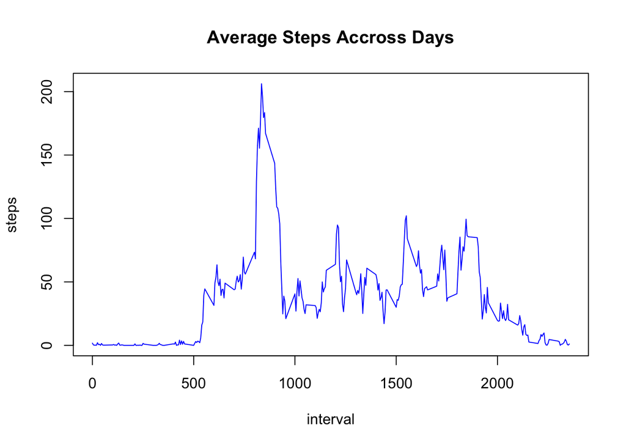

```r
avg_steps_by_interval<-aggregate(steps~interval,df,mean)
with(avg_steps_by_interval,plot(interval,steps,type='l',col='blue',main='Average Steps Accross Days'))
```

```r
max(avg_steps_by_interval[,2])  ## Max Steps
```

```
## [1] 206.1698
```

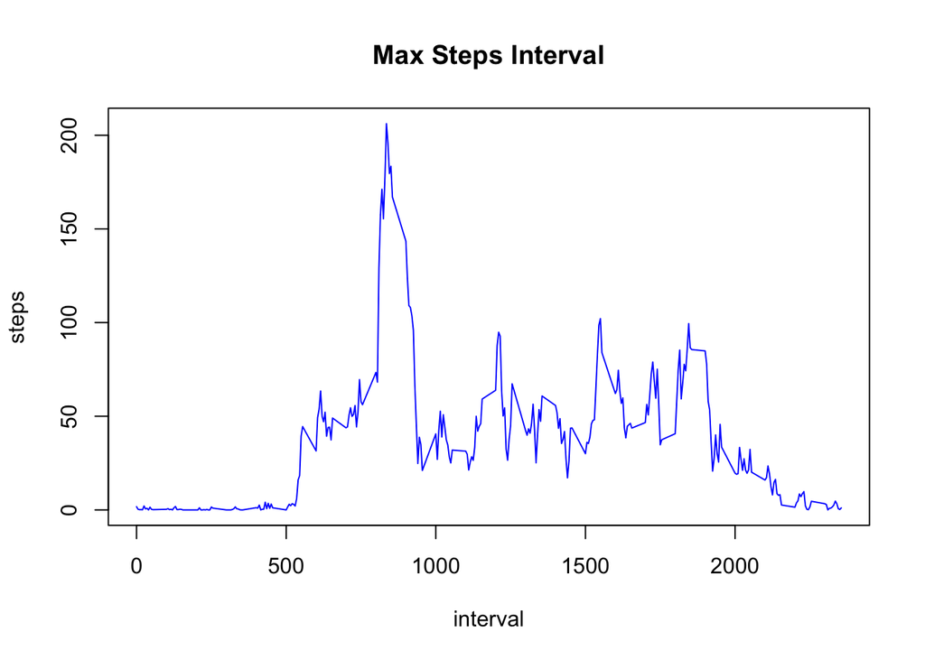

```r
ind<-which(avg_steps_by_interval[,2]==max(avg_steps_by_interval[,2]))
int<-avg_steps_by_interval[ind,1] ## Which 5-minute interval
with(avg_steps_by_interval,plot(interval,steps,type="l",col="blue",main="Max Steps Interval"))
abline(v="int",col="red",lwd=3,lty=2)
```

### Inputing Missing Values

Note that there are a number of days/intervals where there are missing values (coded as 𝙽𝙰). The presence of missing days may introduce bias into some calculations or summaries of the data.

1. Calculate and report the total number of missing values in the dataset (i.e. the total number of rows with 𝙽𝙰s)

```r
sum(is.na(df$steps==TRUE))
```

```
## [1] 2304
```

2. Devise a strategy for filling in all of the missing values in the dataset. The strategy does not need to be sophisticated. For example, you could use the mean/median for that day, or the mean for that 5-minute interval, etc.
3. Create a new dataset that is equal to the original dataset but with the missing data filled in.

```r
na_ind<-which(is.na(df$steps)==TRUE)
na_interval<-df[na_ind,3]
new_df<-df
for(i in 1:length(na_interval)){
  int_ind<-which(avg_steps_by_interval[1]==na_interval[i])
  new_df[na_ind[i],1]<-avg_steps_by_interval[int_ind,2]
}
```

4. Make a histogram of the total number of steps taken each day and calculate and report the mean and median total number of steps taken per day. Do these values differ from the estimates from the first part of the assignment? What is the impact of imputing missing data on the estimates of the total daily number of steps?

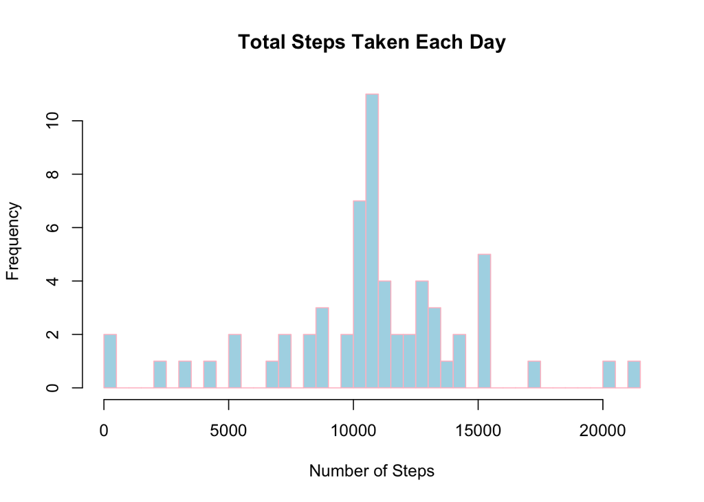

```r
new_steps_by_day<-aggregate(steps~date,new_df,sum)
hist(new_steps_by_day[,2],breaks=dim(new_steps_by_day)[1],col="lightblue",border="pink",main="Total Steps Taken Each Day",xlab="Number of Steps")
```

```r
mean(new_steps_by_day$steps)
```

```
## [1] 10766.19
```

```r
median(new_steps_by_day$steps)
```

```
## [1] 10766.19
```

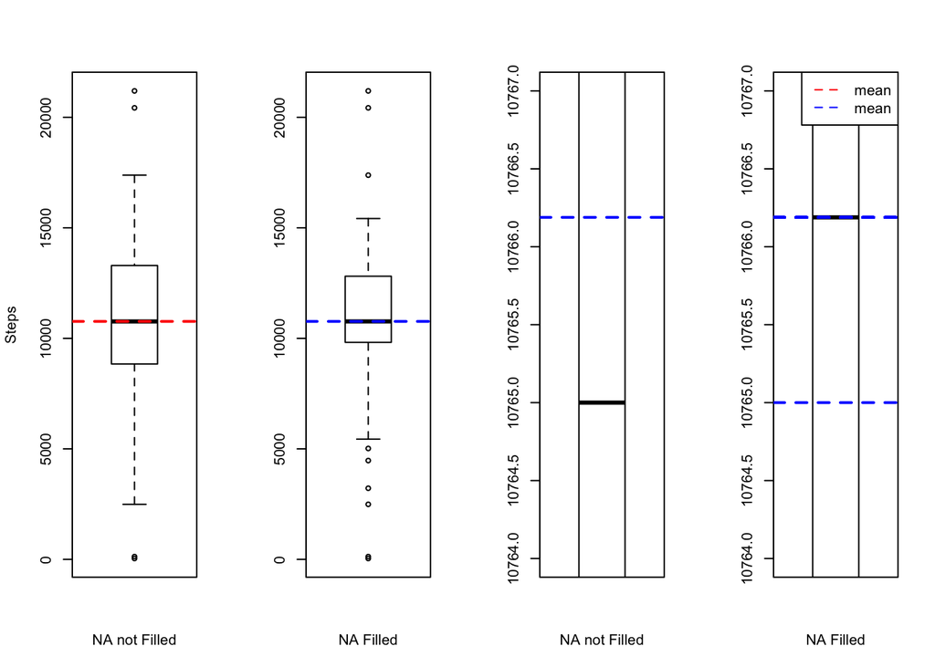

```r
par(mfrow=c(1,4))

boxplot(steps_by_day$steps,xlab="NA not Filled",ylab="Steps")
abline(h=mean(steps_by_day$steps),col="red",lwd=2,lty=2)

boxplot(new_steps_by_day$steps,xlab="NA Filled")
abline(h=mean(new_steps_by_day$steps),col="blue",lwd=2,lty=2)

boxplot(steps_by_day$steps,ylim=c(10764,10767),xlab="NA not Filled")
abline(h=mean(new_steps_by_day$steps),col="blue",lwd=2,lty=2)

boxplot(new_steps_by_day$steps,ylim=c(10764,10767),xlab="NA Filled")
legend("topright",col=c("red","blue"),legend=c("mean","mean"),lty=2)
abline(h=new_steps_by_day$steps,col="blue",lwd=2,lty=2)
```

From the analysis it can be observed that after filling NAs with mean steps number of that 5-min interval, the mean steps per day don’t change (10766.19), while median steps per day slightly increase from 10765 to 10766. The effect of the NAs is thus immaterial.

### Are there differences in the activity patterns between weekdays and weekends?

For this part the 𝚠𝚎𝚎𝚔𝚍𝚊𝚢𝚜() function may be of some help here. Use the dataset with the filled-in missing values for this part.

1. Create a new factor variable in the dataset with two levels – “weekday” and “weekend” indicating whether a given date is a weekday or weekend day.

```r
new_df[,2]<-weekdays(as.Date(new_df[,2]))
new_df[,4]<-ifelse(new_df[,2] %in% c("Monday","Tuesday","Wednesday","Thursday","Friday"),"Weekday","Weekend")
new_df[,4]<-as.factor(new_df[,4])
```

2. Make a panel plot containing a time series plot (i.e. 𝚝𝚢𝚙𝚎 = “𝚕”) of the 5-minute interval (x-axis) and the average number of steps taken, averaged across all weekday days or weekend days (y-axis). See the README file in the GitHub repository to see an example of what this plot should look like using simulated data.

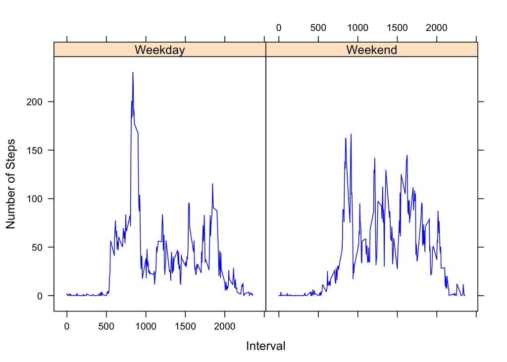

```r
library(lattice)
avg_steps_by_interval_V4<-aggregate(steps~interval*V4,new_df,mean)
xyplot(steps~interval|V4,data=avg_steps_by_interval_V4,type="l",col="blue",xlab="Interval",ylab="Number of Steps")
```